# Statistical inference with the GSS data

## Setup

### Load packages

```r
library(ggplot2)
library(dplyr)
library(statsr)
```

### Load data

Make sure your data and R Markdown files are in the same directory. When loaded your data file will be called `gss`. Delete this note when before you submit your work.

```r
load("gss.Rdata")
```

## Part 1: Data

### Background

The GSS gathers data on contemporary American society in order to monitor and explain trends and constants in attitudes, behaviors, and attributes. Hundreds of trends have been tracked since 1972. The basic purpose of the GSS is to gather information about contemporary American society in order to explain trends in attitudes and behaviors. The GSS is a gold standard of unbiased social science research. For over 40 years researchers and scholars have relied on the data from the GSS to understand observable attributes of different people and groups in America. This research is then used to address issues of public interest and public policy like national spending, immigration, and confidence in various institutions. The GSS is also one of the most popular teaching tools for a variety of subjects in colleges and universities across the country.

### Methodology

From the GS5 website, Participants were selected after random selection of households from across the United States. This ensures that the results of the survey are scientifically valid since all households from across the country had an equal chance of being selected for this survey. Selected participants are interviewed one-one in their homes, or in another place such as a coffee shop or library. If needed, over the phone is also an option for participants. The survey is currently conducted every two years.

### Observations on Generalizability, Causality, and Bias.

There is **random sampling** since every household is likely be surveyed, hence results are **generaliazable** to the whole population. GS5 is an **observational study** since there is **no random assignment** so only association can be inferred but **not causation**

However, there may be some biases present: * There may be under-reporting and over-reporting since responses are categorical i.e. downplaying when undesirable and exaggerating when desirable. * Selected participants may choose not to respond and decline the survey

## Part 2: Research question

`Is there a relationship between respondent's religious preference and their political party of affiliation ?`

This is an interesting question as this explores how religious preference is associated with political party. It may be interesting to note whether some religious preference are more likely to be affiliated to a particular party.

To analyse this research questions, Variables need are `relig`, `partyid` and `year`

```r
q1 <- select(gss, year, relig, partyid) %>%
  na.omit()%>%
  filter(relig != "None") %>%
mutate(recent = ifelse(year >= "2006", "R", "O") )
```

## Part 3: Exploratory data analysis

Before we go ahead We can take a look at the frequency of responses across Religious preference and then consider their proportion.

```r
prop.table(table(q1$relig, q1$partyid), 2)
```

```
##
##                           Strong Democrat Not Str Democrat Ind,Near Dem
##   Protestant                 0.6680707666     0.6226760692 0.5960122148
##   Catholic                   0.2606811891     0.3091858229 0.3100413149
##   Jewish                     0.0350222650     0.0316878835 0.0312556134
##   None                       0.0000000000     0.0000000000 0.0000000000
##   Other                      0.0169695511     0.0157523583 0.0346685827
##   Buddhism                   0.0021663257     0.0027475044 0.0055685288
##   Hinduism                   0.0006017571     0.0016485026 0.0014370397
##   Other Eastern              0.0003610543     0.0002747504 0.0012574097
##   Moslem/Islam               0.0025273799     0.0028390878 0.0035925992
##   Orthodox-Christian         0.0014442171     0.0017400861 0.0028740794
##   Christian                  0.0091467084     0.0094330983 0.0100592779
##   Native American            0.0004814057     0.0007326678 0.0005388899
##   Inter-Nondenominational    0.0025273799     0.0012821687 0.0026944494
##
##                            Independent Ind,Near Rep Not Str Republican
##   Protestant              0.6062980699 0.6666666667       0.7282647373
##   Catholic                0.3140327964 0.2722524977       0.2330684379
##   Jewish                  0.0148019155 0.0140781108       0.0122168189
##   None                    0.0000000000 0.0000000000       0.0000000000
##   Other                   0.0274270788 0.0242960945       0.0100818408
##   Buddhism                0.0037730373 0.0013623978       0.0003558297
##   Hinduism                0.0033376868 0.0004541326       0.0004744396
##   Other Eastern           0.0015962850 0.0006811989       0.0002372198
##   Moslem/Islam            0.0031925700 0.0013623978       0.0002372198
##   Orthodox-Christian      0.0024669859 0.0022706630       0.0015419286
##   Christian               0.0177042519 0.0136239782       0.0115051595
##   Native American         0.0008707009 0.0004541326       0.0001186099
##   Inter-Nondenominational 0.0044986214 0.0024977293       0.0018977583
##
##                           Strong Republican  Other Party
##   Protestant                   0.7562771380 0.6048265460
##   Catholic                     0.2072871437 0.2428355958
##   Jewish                       0.0094393053 0.0361990950
##   None                         0.0000000000 0.0000000000
##   Other                        0.0117047385 0.0708898944
##   Buddhism                     0.0013215027 0.0105580694
##   Hinduism                     0.0000000000 0.0015082956
##   Other Eastern                0.0003775722 0.0000000000
##   Moslem/Islam                 0.0001887861 0.0015082956
##   Orthodox-Christian           0.0015102888 0.0000000000
##   Christian                    0.0092505192 0.0301659125
##   Native American              0.0000000000 0.0000000000
##   Inter-Nondenominational      0.0026430055 0.0015082956
```

The way to interpret the table above is that for each column (“Strong Democrat”,“Not Str Democrat”, …) the proportion of respondents that indicated their religious preference as “Protestant”, “Catholic”, …) Note that the column sums up to 1.

We can go on to represent this on a plot

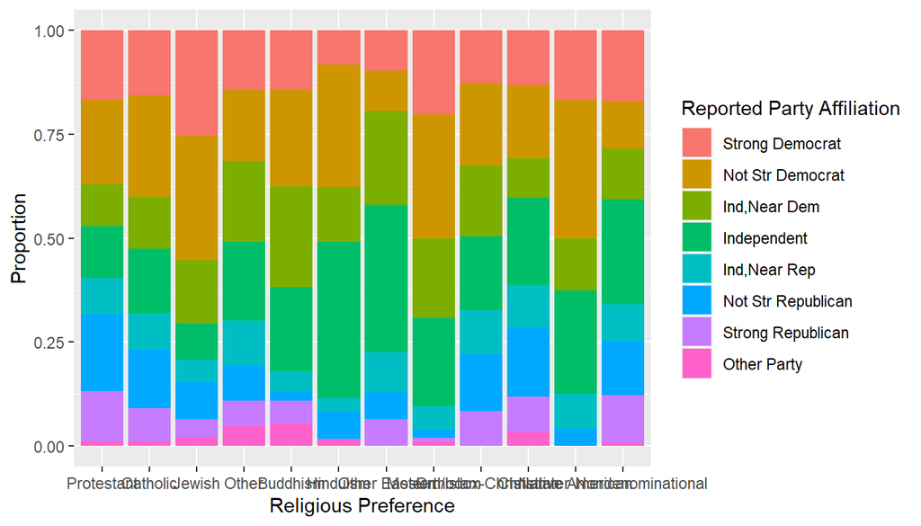

```r
ggplot(q1) + aes(x=relig, fill=partyid) + geom_bar(position = "fill") + xlab("Religious Preference") + ylab("Proportion") + scale_fill_discrete(name="Reported Party Affiliation")
```

However, let’s look at how the data has changed in recent years.

```r
q1since06 <- filter(q1, year >= 2006)
```

Let us take a look at how it has chnaged in recent years

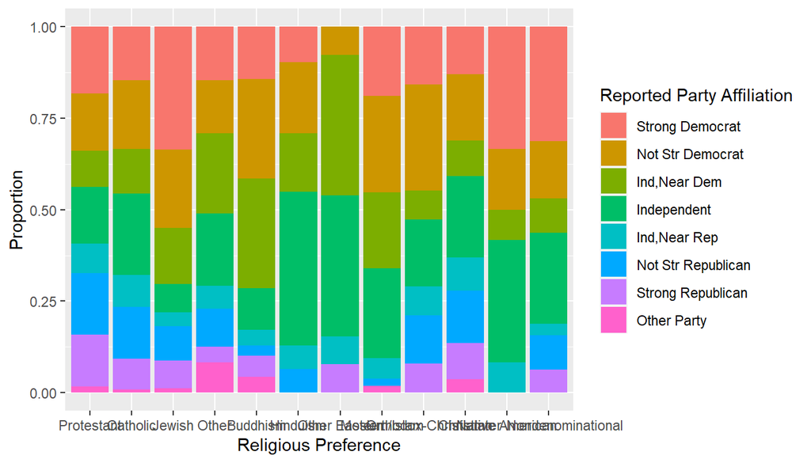

```r
ggplot(q1since06) + aes(x=relig, fill=partyid) + geom_bar(position = "fill") + xlab("Religious Preference") + ylab("Proportion") + scale_fill_discrete(name="Reported Party Affiliation")
```

Now let us compare both graphs visually

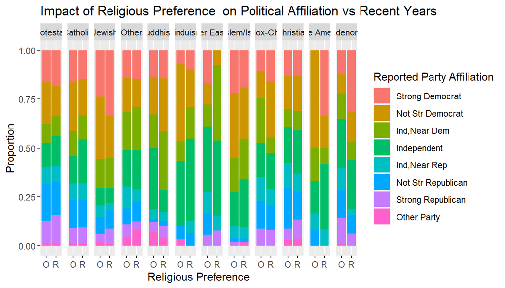

```r
ggplot(data = q1) + aes(x=recent, fill=partyid) + geom_bar(position = "fill") + facet_grid(.~relig) + xlab("Religious Preference") + ylab("Proportion") + labs(title = "Impact of Religious Preference  on Political Affiliation vs Recent Years") + scale_fill_discrete(name="Reported Party Affiliation")
```

## Part 4: Inference

We perform statistical inference on the results.

- Hypothesis

The **null hypothesis** is that the respondent’s party affiliation and their religious preference are independent variables.

The **alternative hypothesis** is that the respondent’s party affiliation and their religious preference are dependent.

- Statistical Method

```r
str(q1)
```

```
## 'data.frame':    50481 obs. of  4 variables:
##  $ year   : int  1972 1972 1972 1972 1972 1972 1972 1972 1972 1972 ...
##  $ relig  : Factor w/ 13 levels "Protestant","Catholic",..: 3 2 1 5 1 1 2 3 1 1 ...
##  $ partyid: Factor w/ 8 levels "Strong Democrat",..: 3 2 4 2 1 3 3 3 1 1 ...
##  $ recent : chr  "O" "O" "O" "O" ...
##  - attr(*, "na.action")= 'omit' Named int [1:500] 111 737 746 994 1158 1379 1389 1421 1428 1474 ...
##   ..- attr(*, "names")= chr [1:500] "111" "737" "746" "994" ...
```

Since the dataset consists of **two** categorical variables (religious preference and reported party affiliation), the most appropriate test to be used is the **chi-square test of independence**. This is used when comparing 2 categorical variables where one of the variables has more than 2 levels

- Check for conditions

Independence: This is assumed to be true based on the sampling methodology used in the GSS, as it uses random sampling. Furthermore, the size of the sample is less than 10% of the population, and each result is only counted in one cell.

- Perform the inference tests

```r
chisq.test(q1$relig,q1$partyid)
```

```
##
##  Pearson's Chi-squared test
##
## data:  q1$relig and q1$partyid
## X-squared = 1220.3, df = 77, p-value < 2.2e-16
```

This resulted in an approximation error because many of the expected values will be very small and therefore the approximations of p may not be right.

Therefore, let us use simulate p values.

```r
chisq.test(q1$relig,q1$partyid, simulate.p.value = TRUE)
```

```
##
##  Pearson's Chi-squared test with simulated p-value (based on 2000
##  replicates)
##
## data:  q1$relig and q1$partyid
## X-squared = 1220.3, df = NA, p-value = 0.0004998
```

### **Results**

The high X-squared statistic with 77 degrees of freedom leads to very low p-value i.e. 0.0004998. Since the p-value is below alpha (0.05), we can conclude that there is sufficient evidence to **reject null hypothesis**.

In the context of the research question, it means that there is evidence that the party affiliations vary by religious preference.

However, this result cannot be used to determine causality.